# Stepanyants_Project

Maxim Stepanyants

```r
library(tidyverse)
library(ggplot2)
```

# Исследование: проверка наличия контактного влияние древнегреческого alla на древнеармянское ayl

## Репозиторий

https://github.com/robibistspark/r_data_analysis_project

## Введение

В древнеармянском языке есть единица ayl, тогда как в древнегреческом есть когнатные ей alla/allos (диахронически связанные: союз возник из “местоимения”). Др.-арм. единица ayl достаточно частотна (служебное слово), имеет, как и др.-греч. alla, три функции: 1) уступительная ‘though’, 2) заместительная ‘but rather’, 3) неидентичность ‘other, else’ (согласно моим наблюдениям по корпусу и изучению словарей; иногда выделяются другие, но, как кажется, они более периферийны).

В то время как внутрення форма (и специальные исследования, см. Allan R.J. Ancient Greek adversative particles in contrast. Denizot C., Spevak O. (eds.) Pragmatic approaches to Latin and Ancient Greek. Amsterdam: J. Benjamins Pub. Co, 2017.) позволяют понять путь диахронического развития для др.-греч. единицы, др.-арм. единица, обладает всеми этими функциями, но путь их семантического развития не ясен. Известно, что др.-арм. переводы Евангелий делались главным образом с др.-греч. языка (в первую очередь в 5 веке) и что многие конструкции были калькированы. Задача в том, чтобы попробовать проверить, не было ли контактного влияния.

Исследование опирается на дипломную работу автора, публикацию (2023, https://journals.rcsi.science/1605-7880/article/view/126435). В имеющейся индоевропеистической литературе по теме статистические выводы не делались, см. Klein, Jared S. 2022. Adversative Conjunction and Neighboring Discourse Features in Old Church Slavic (Codex Marianus), with Comparative Notes on the Same Phenomena in Greek, Gothic and Classical Armenian. Transactions of the Philological Society 120(1). 128–183. (doi:10.1111/1467-968X.12231).

## Цель

Количественно оценить, возможно ли, что древнеармянское ayl - калька древнегреческого alla в ряде своих употреблений?

## Гипотезы

1. Уступительные употребления ayl являются семантическими кальками, a остальные два типа употреблений не имеют контактного происхождения.
2. Разницы в паттернах заимствований в двух Евангелиях нет.

```r
data <- read_csv('data.csv') |> as.data.frame()
head(data)
```

```
##   Token_ID_Greek Token_Greek Gospel Token_ID_Armenian Token_Armenian Function
## 1         342616        ἀλλ’   JOHN            800741            ayl    SUBST
## 2         342961        ἀλλ’   JOHN            801061            aył    ADVER
## 3         342531        ἀλλ’   JOHN            800667            aył    ADVER
## 4         351330        ἀλλὰ   JOHN                NA           <NA>    SUBST
## 5         351611        ἄλλα   JOHN            808772            áył     UNID
## 6         351668        ἀλλ’   JOHN            808828            aył    SUBST
##   comment Location Greek_found Armenian_found where_found
## 1    <NA>     1.13           1              1  both_langs
## 2       ?     1.31           1              1  both_langs
## 3  SUBST?     1.80           1              1  both_langs
## 4    <NA>    10.10           1              0     only_Gr
## 5     ews    10.16           1              1  both_langs
## 6    OPP?    10.18           1              1  both_langs
```

## Используемые данные

Из доступного при регистрации корпуса PROEIL (http://foni.uio.no/proiel/) скачаны результаты поиска в Евангелиях от Иоанна и от Луки (по леммам ayl, а также alla и allos), содержащие исследуемые единицы. Выравнивание (через JOIN) было сделано в pandas. Часть примеров имела соответсвующие единицы в обоих языках, а часть - только в каком-то одном. Из рассмотрения были исключены 21 др.-арм. пример и 17 др.-греч. примеров, если в них было больше одного вхождения единиц, т.к. это затрудняло выравнивание (при этом немалая доля этих примеров относятся к одному и тожму же контексту - “переводной единицы”). Контексты были вручную очищены от ошибок токенизатора в интересующих местах.

## Разметка

Контексты размечены по функции интересующей единицы в контексте с помощью английских и русских переводов Евангелий и данных морфологической разметки из PROEIL и с сайта проекта Arak29 (https://bible.zoraweb.com/index.htm). Затем 13 контекстов были исключены из рассмотрения (в них были эквивалентные предложения, идиоматические употребления ayl, ошибки в текст, единицы встречались в разных стихах). Всего в итоговых датасет вошло 206 контекстов. Оговоримся, что разметка сделана техническим образом и для большего доверия к данным требует проверки экперта по обоим древним языкам (около 40 контекстов вызывали сомнение, но были сохранены).

## Переменные

Евангелие-источник, функция в контектсе, наличие единицы в др.-арм. и наличие в др.-греч, эти же две в кортеже. Контексты размечены по трём функциям, которые есть у исследуемых единиц. Так же в датасете есть, но не исследуются: обозначение главы и стиха, словоформа токена и его ID из PROEIL для каждого языка, комментарий при разметке. В датасете есть пустые значения, наследуемые исходным данным.

## Описательная статистика

Распределение частотностей словоформ для древнегреческого.

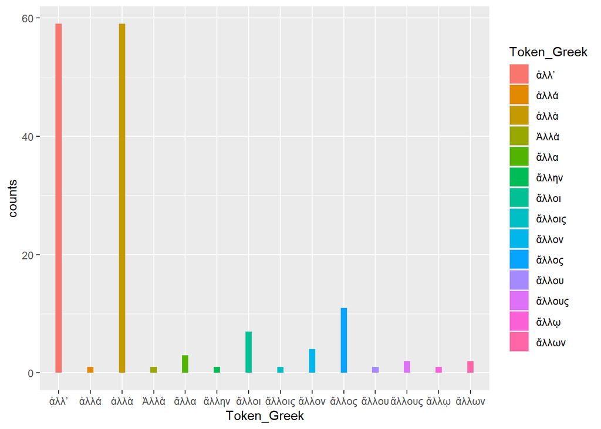

```r
data |>
  mutate(value = TRUE) |>
  pivot_wider(names_from = "Token_Greek",
              values_from = "value", values_fill = FALSE) |>
  select(-c('NA')) |>
  summarise(across(where(is.logical), sum, na.rm = TRUE)) |>
  pivot_longer(cols=everything(), names_to = "Token_Greek", values_to = "counts") |>
  ggplot() +
  geom_col(aes(x=Token_Greek, y=counts, fill=Token_Greek), width = .2)
```

Распределение частотностей словоформ для древнеармянского.

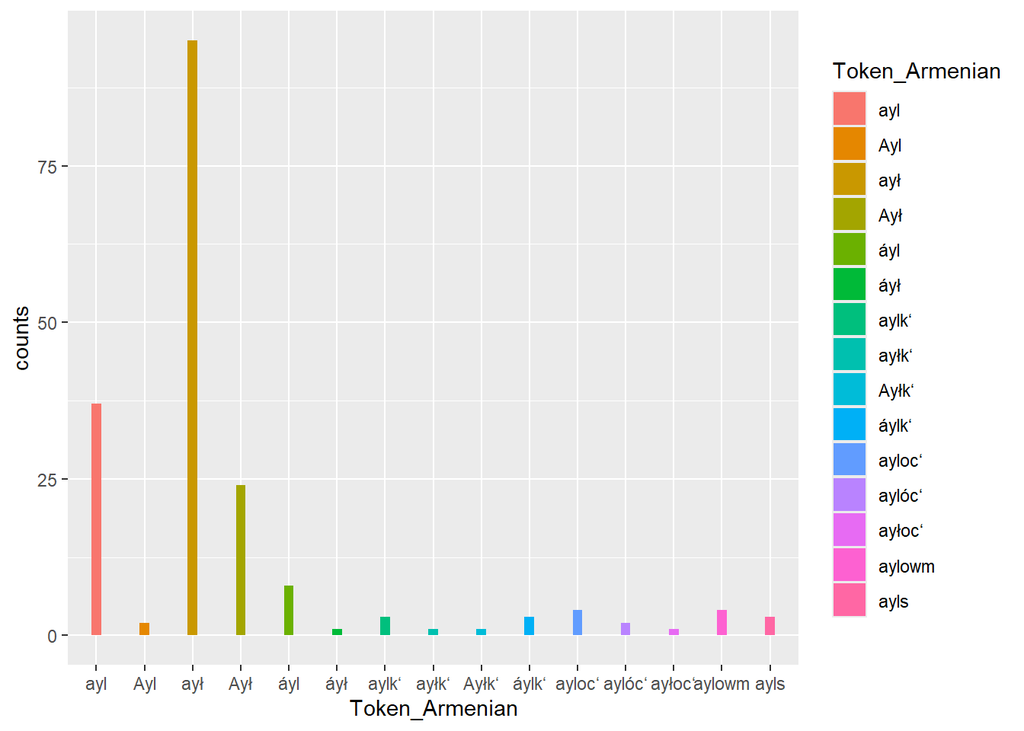

```r
data |>
  mutate(value = TRUE) |>
  pivot_wider(names_from = "Token_Armenian",
              values_from = "value", values_fill = FALSE) |>
  select(-c('NA')) |>
  summarise(across(where(is.logical), sum, na.rm = TRUE)) |>
  pivot_longer(cols=everything(), names_to = "Token_Armenian", values_to = "counts") |>
  ggplot() +
  geom_col(aes(x=Token_Armenian, y=counts, fill=Token_Armenian), width = .2)
```

Распределение наличия единицы в обоих фрагментах, источников, функций.

```r
data <- data[c('Gospel', 'Function', 'where_found', 'Greek_found', 'Armenian_found')]
head(data)
```

```
##   Gospel Function where_found Greek_found Armenian_found
## 1   JOHN    SUBST  both_langs           1              1
## 2   JOHN    ADVER  both_langs           1              1
## 3   JOHN    ADVER  both_langs           1              1
## 4   JOHN    SUBST     only_Gr           1              0
## 5   JOHN     UNID  both_langs           1              1
## 6   JOHN    SUBST  both_langs           1              1
```

```r
data |> mutate_all(as.factor) |> summary()
```

```
##   Gospel     Function      where_found  Greek_found Armenian_found
##  JOHN:132   ADVER:71   both_langs:136   0: 53       0: 17
##  LUKE: 74   SUBST:79   only_Arm  : 53   1:153       1:189
##             UNID :56   only_Gr   : 17
```

```r
data |> mutate_all(as.factor) |> filter(Gospel == 'JOHN') |> summary()
```

```
##   Gospel     Function      where_found Greek_found Armenian_found
##  JOHN:132   ADVER:47   both_langs:99   0: 18       0: 15
##  LUKE:  0   SUBST:58   only_Arm  :18   1:114       1:117
##             UNID :27   only_Gr   :15
```

```r
data |> mutate_all(as.factor) |> filter(Gospel == 'LUKE') |> summary()
```

```
##   Gospel    Function      where_found Greek_found Armenian_found
##  JOHN: 0   ADVER:24   both_langs:37   0:35        0: 2
##  LUKE:74   SUBST:21   only_Arm  :35   1:39        1:72
##            UNID :29   only_Gr   : 2
```

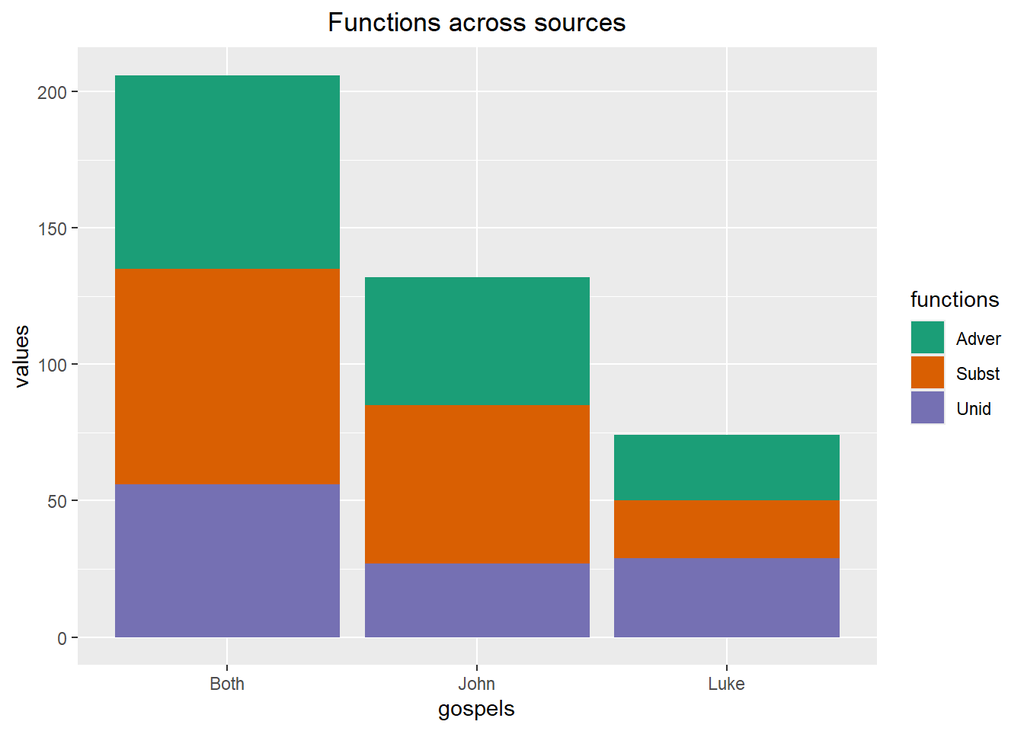

```r
gospels <- c(rep("Both", 3), rep("John", 3),
            rep("Luke", 3))

functions <- rep(c("Adver", "Subst", "Unid"), 3)

values <- c(71, 79, 56, 47, 58, 27, 24, 21, 29)

dataframe <- data.frame(gospels, functions, values)

ggplot(dataframe, aes(fill = functions,
                      y = values, x = gospels)) +
geom_bar(position = "stack", stat = "identity") +
ggtitle("Functions across sources") +
theme(plot.title = element_text(hjust = 0.5)) +
scale_fill_brewer(palette = "Dark2")
```

[figure not shown]

```r
gospels <- c(rep("Both", 3), rep("John", 3),
            rep("Luke", 3))

functions <- rep(c("Both", "Ancient Greek", "Classical Armenian"), 3)

values <- c(136, 53, 17, 99, 18, 15, 37, 35, 2)

dataframe <- data.frame(gospels, functions, values)

ggplot(dataframe, aes(fill = functions,
                      y = values, x = gospels)) +
geom_bar(position = "stack", stat = "identity") +
ggtitle("Presence of units in question in languages across sources") +
theme(plot.title = element_text(hjust = 0.5)) +
scale_fill_brewer(palette = "Dark2")
```

## Методы анализа

Статистический тест Хи-квадрат Пирсона. Применяется для оценки связи между совместно встречающимися переменными. Необходимые допущения: случайная выборка данных, независимость наблюдений, не слишком мало наблюдений. Применяется к таблицам сопряжённости для каждой из трёх функций и наличия в др.-греч. тексте единицы alla/ allos. Рассматриваем отдельно все данные вместе и два Евангелия.

### Проверим наличие связи на табличке со всеми функциями

```r
for_table <- data[c('Function', 'Greek_found', 'Armenian_found')] |> filter(Armenian_found == 1)
for_table <- for_table[c('Function', 'Greek_found')]
cont_table = table(for_table)
cont_table
```

```
##         Greek_found
## Function  0  1
##    ADVER 19 49
##    SUBST 11 65
##    UNID  23 22
```

Применим тест.

```r
chisq.test(cont_table)
```

```
##
##  Pearson's Chi-squared test
##
## data:  cont_table
## X-squared = 18.802, df = 2, p-value = 8.263e-05
```

Отобразим ожидаемые значения.

```r
chisq.test(cont_table)$expected
```

```
##         Greek_found
## Function        0        1
##    ADVER 19.06878 48.93122
##    SUBST 21.31217 54.68783
##    UNID  12.61905 32.38095
```

Далее будем рассматривать конкретные функции и разные Евангелия.

### Проверим данные из обоих Евангелий вместе

Уступительное употребление

```r
for_table <- data[c('Function', 'Greek_found', 'Armenian_found')] |> filter(Armenian_found == 1) |> filter(Function == 'ADVER')
for_table <- for_table[c('Function', 'Greek_found')]
cont_table = table(for_table)
cont_table
```

```
##         Greek_found
## Function  0  1
##    ADVER 19 49
```

Применим тест.

```r
chisq.test(cont_table)
```

```
##
##  Chi-squared test for given probabilities
##
## data:  cont_table
## X-squared = 13.235, df = 1, p-value = 0.0002747
```

Тест хи-квадрат при значениях X-squared = 13.235, df = 1 показал p-value < 0.01, т.е. при уровне значимости 0.99 в этих данных есть связь (альтернативная гипотеза). Это означает, что обнаруживается связь между употреблениями др.-арм. ayl в уступительной функции и наличием в оригинальном тексте alla/allos.

Заместительное употребление

```r
for_table <- data[c('Function', 'Greek_found', 'Armenian_found')] |> filter(Armenian_found == 1) |> filter(Function == 'SUBST')
for_table <- for_table[c('Function', 'Greek_found')]
cont_table = table(for_table)
cont_table
```

```
##         Greek_found
## Function  0  1
##    SUBST 11 65
```

Применим тест.

```r
chisq.test(cont_table)
```

```
##
##  Chi-squared test for given probabilities
##
## data:  cont_table
## X-squared = 38.368, df = 1, p-value = 5.857e-10
```

Тест хи-квадрат при значениях X-squared = 38.368, df = 1 показал p-value < 0.01, т.е. при уровне значимости 0.99 в этих данных есть связь (альтернативная гипотеза). Значит, связь между наличием в оригинале alla/allos и употреблением ayl в этой функции тоже есть.

Неидентическое употребление

```r
for_table <- data[c('Function', 'Greek_found', 'Armenian_found')] |> filter(Armenian_found == 1) |> filter(Function == 'UNID')
for_table <- for_table[c('Function', 'Greek_found')]
cont_table = table(for_table)
cont_table
```

```
##         Greek_found
## Function  0  1
##     UNID 23 22
```

Применим тест.

```r
chisq.test(cont_table)
```

```
##
##  Chi-squared test for given probabilities
##
## data:  cont_table
## X-squared = 0.022222, df = 1, p-value = 0.8815
```

Тест хи-квадрат при значениях X-squared = 0.022222, df = 1 показал p-value > 0.01, т.е. при уровне значимости 0.99 в этих данных не обнаруживается связь (нулевая гипотеза). Значит, связь между наличием в оригинале alla/allos и употреблением ayl в этой функции не установлена на этих данных.

### Проверим данные для Евангелия от Иоанна

Уступительное употребление

```r
for_table <- data[c('Gospel', 'Function', 'Greek_found', 'Armenian_found')] |> filter(Gospel == 'JOHN') |> filter(Armenian_found == 1) |> filter(Function == 'ADVER')
for_table <- for_table[c('Function', 'Greek_found')]
cont_table = table(for_table)
cont_table
```

```
##         Greek_found
## Function  0  1
##    ADVER 11 34
```

Применим тест.

```r
chisq.test(cont_table)
```

```
##
##  Chi-squared test for given probabilities
##
## data:  cont_table
## X-squared = 11.756, df = 1, p-value = 0.0006066
```

Тест хи-квадрат при значениях X-squared = 11.756, df = 1 показал p-value < 0.01, т.е. при уровне значимости 0.99 в этих данных есть связь (альтернативная гипотеза). Это означает, что обнаруживается связь между употреблениями др.-арм. ayl в уступительной функции и наличием в оригинальном тексте alla/allos.

Заместительное употребление

```r
for_table <- data[c('Gospel', 'Function', 'Greek_found', 'Armenian_found')] |> filter(Gospel == 'JOHN') |> filter(Armenian_found == 1) |> filter(Function == 'SUBST')
for_table <- for_table[c('Function', 'Greek_found')]
cont_table = table(for_table)
cont_table
```

```
##         Greek_found
## Function  0  1
##    SUBST  4 51
```

Неправильно применять тест, т.к. в одной ячейке всего 4 наблюдения. Но в целом без статистики при 4 против 51 не ожидаем связи.

Неидентическое употребление

```r
for_table <- data[c('Gospel', 'Function', 'Greek_found', 'Armenian_found')] |> filter(Gospel == 'JOHN') |> filter(Armenian_found == 1) |> filter(Function == 'UNID')
for_table <- for_table[c('Function', 'Greek_found')]
cont_table = table(for_table)
cont_table
```

```
##         Greek_found
## Function  0  1
##     UNID  3 14
```

Неправильно применять тест, т.к. есть 3 наблюдения. Но в целом и без статистики при 3 против 14 не ожидаем связи.

### Проверим данные для Евангелия от Луки

Уступительное употребление

```r
for_table <- data[c('Gospel', 'Function', 'Greek_found', 'Armenian_found')] |> filter(Gospel == 'LUKE') |> filter(Armenian_found == 1) |> filter(Function == 'ADVER')
for_table <- for_table[c('Function', 'Greek_found')]
cont_table = table(for_table)
cont_table
```

```
##         Greek_found
## Function  0  1
##    ADVER  8 15
```

Применим тест.

```r
chisq.test(cont_table)
```

```
##
##  Chi-squared test for given probabilities
##
## data:  cont_table
## X-squared = 2.1304, df = 1, p-value = 0.1444
```

Тест хи-квадрат при значениях X-squared = 2.1304, df = 1 показал p-value > 0.01, т.е. при уровне значимости 0.99 в этих данных связи нет (нулевая гипотеза). Это отличается от первого рассмотренного Евангелия.

Заместительное употребление

```r
for_table <- data[c('Gospel', 'Function', 'Greek_found', 'Armenian_found')] |> filter(Gospel == 'LUKE') |> filter(Armenian_found == 1) |> filter(Function == 'SUBST')
for_table <- for_table[c('Function', 'Greek_found')]
cont_table = table(for_table)
cont_table
```

```
##         Greek_found
## Function  0  1
##    SUBST  7 14
```

Применим тест.

```r
chisq.test(cont_table)
```

```
##
##  Chi-squared test for given probabilities
##
## data:  cont_table
## X-squared = 2.3333, df = 1, p-value = 0.1266
```

Тест хи-квадрат при значениях X-squared = 2.3333, df = 1 показал p-value > 0.01, т.е. при уровне значимости 0.99 в этих данных связи нет (нулевая гипотеза). Это отличается от первого рассмотренного Евангелия (если верить тому результату).

Неидентическое употребление

```r
for_table <- data[c('Gospel', 'Function', 'Greek_found', 'Armenian_found')] |> filter(Gospel == 'LUKE') |> filter(Armenian_found == 1) |> filter(Function == 'UNID')
for_table <- for_table[c('Function', 'Greek_found')]
cont_table = table(for_table)
cont_table
```

```
##         Greek_found
## Function  0  1
##     UNID 20  8
```

Применим тест.

```r
chisq.test(cont_table)
```

```
##
##  Chi-squared test for given probabilities
##
## data:  cont_table
## X-squared = 5.1429, df = 1, p-value = 0.02334
```

## Обобщение

В целом связь между ayl и наличием в оригинальном контексте alla/allos обнаруживается. При рассмотрении данных обоих Евангелий вместе обнаруживается статистически значимая связь для уступительной и заместительной функций, а для неидентической не обнаруживается. В Евангелии от Иоанна обнаруживается связь для уступительной функции, а для двух других тест применять неправильно. В Евангелии от Луки для уступительной функции и для заместительной функции связи не обнаружено, вразрез результатам аналогичных тестов. Отчасти вразрез предыдущему, для неидентической функции при понижении уровня доверия до 0.95 (достаточно адекватного для языковых данных) связь выявляется.

## Заключение

Гипотезы подтвердились лишь частично. Для дальнейшего развития исследования (насколько это возможно) полезно было бы увеличить объёмы выборок (самое понятное - взять ещё два доступных Евангелия), учесть данные о переводчиках, проверить разметку. Для более правильной лингвистической интерпретации нужно привлекать данные из непереводных текстов. В частности, хотелось бы сравнить частотность функций в переводных текстах и в оригинальных (но для этого сложнее сделать разметку). Можно ещё использовать Точный тест Фишера (таблички сопряжённости маленькие) или Cramer’s V. В этой работе я строил таблицы сопряжённости при фильтрации по признаку “в контексте употреблена др.-арм. единица ayl” - а можно, наоборот, использовать таблицы следующего вида: др.-арм. по Оx, др-гр. по Оy, на каждой оси количество случаев есть/нет. Базовые сравнения вроде частотности осложнены необходимостью разметки на двух языках (важны конкретные функции).